# Survival Analysis: Ovarian Cancer

Nesma Magdi

October 18, 2019

## Ovarian Cancer:

Survival in a randomised trial comparing two treatments for ovarian cancer. Format

Treatment of patients with advanced ovarian carcinoma (stages IIIB and IV) using either cyclophosphamide alone (1 g/m2) or cyclophosphamide (500 mg/m2) plus adriamycin (40 mg/m2) by iv injection every 3 weeks each produced partial regression in approximately one third of the patients.

```r
data("ovarian")
attach(ovarian)

Status <- ifelse(fustat == 0,"Death", "Censord")
Progression <- ifelse(resid.ds == 1, "No Progression", "Progression")
Treatment <- ifelse(rx == 1, "Endoxan alone", "Endoxan + Adria")
Performance <- ifelse(ecog.ps == 1, "High", "Low")
dummy_Age <- ifelse(age >= 50 ,"Old","Young")

ex <- data.frame(Status, Progression, Treatment, Performance, dummy_Age)

Ovarian <- cbind(ovarian, ex)

Ovarian$dummy_Age <- factor(Ovarian$dummy_Age)
Ovarian$Status<- factor(Ovarian$Status)
Ovarian$Progression <- factor(Ovarian$Progression)
Ovarian$Treatment <- factor(Ovarian$Treatment)
Ovarian$Performance <- factor(Ovarian$Performance)


write.csv(Ovarian, file="ovarian.csv")
ovarian <- read.csv(choose.files(), header = T)
attach(ovarian)
```

## Descrition:

```
##                         Description
## futime   Survival or Censoring time
## fustat             Censoring status
## age                    Age in years
## resid.ds   Residual disease present
## rx                  Treatment Group
## ecog.ps     ECOG Performance Status
```

```r
summary(ovarian)
```

```
##        X             futime           fustat            age
##  Min.   : 1.00   Min.   :  59.0   Min.   :0.0000   Min.   :38.89
##  1st Qu.: 7.25   1st Qu.: 368.0   1st Qu.:0.0000   1st Qu.:50.17
##  Median :13.50   Median : 476.0   Median :0.0000   Median :56.85
##  Mean   :13.50   Mean   : 599.5   Mean   :0.4615   Mean   :56.17
##  3rd Qu.:19.75   3rd Qu.: 794.8   3rd Qu.:1.0000   3rd Qu.:62.38
##  Max.   :26.00   Max.   :1227.0   Max.   :1.0000   Max.   :74.50
##     resid.ds           rx         ecog.ps          Status
##  Min.   :1.000   Min.   :1.0   Min.   :1.000   Censord:12
##  1st Qu.:1.000   1st Qu.:1.0   1st Qu.:1.000   Death  :14
##  Median :2.000   Median :1.5   Median :1.000
##  Mean   :1.577   Mean   :1.5   Mean   :1.462
##  3rd Qu.:2.000   3rd Qu.:2.0   3rd Qu.:2.000
##  Max.   :2.000   Max.   :2.0   Max.   :2.000
##          Progression           Treatment  Performance dummy_Age
##  No Progression:11   Endoxan + Adria:13   High:14     Old  :20
##  Progression   :15   Endoxan alone  :13   Low :12     Young: 6
##
##
##
##
```

## First, Analysis of Variance:

# 1- Age:

```r
AGE_mean <- as.data.frame(ovarian %>%
              summarise(count = n(), mean = mean(age, na.rm = T), sd = sd(age, na.rm = T)))
AGE_mean
```

```
##   count     mean       sd
## 1    26 56.16544 10.10036
```

```r
summary(ovarian$age)
```

```
##    Min. 1st Qu.  Median    Mean 3rd Qu.    Max.
##   38.89   50.17   56.85   56.17   62.38   74.50
```

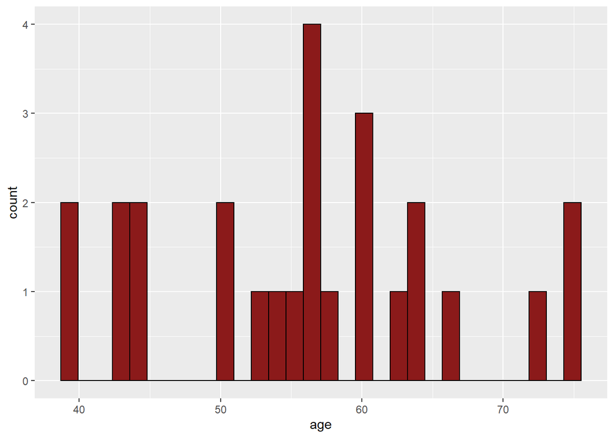

```r
ggplot(ovarian, aes(x= age)) +
  geom_histogram(aes(y=..count..), color = "black", fill="firebrick4")
```

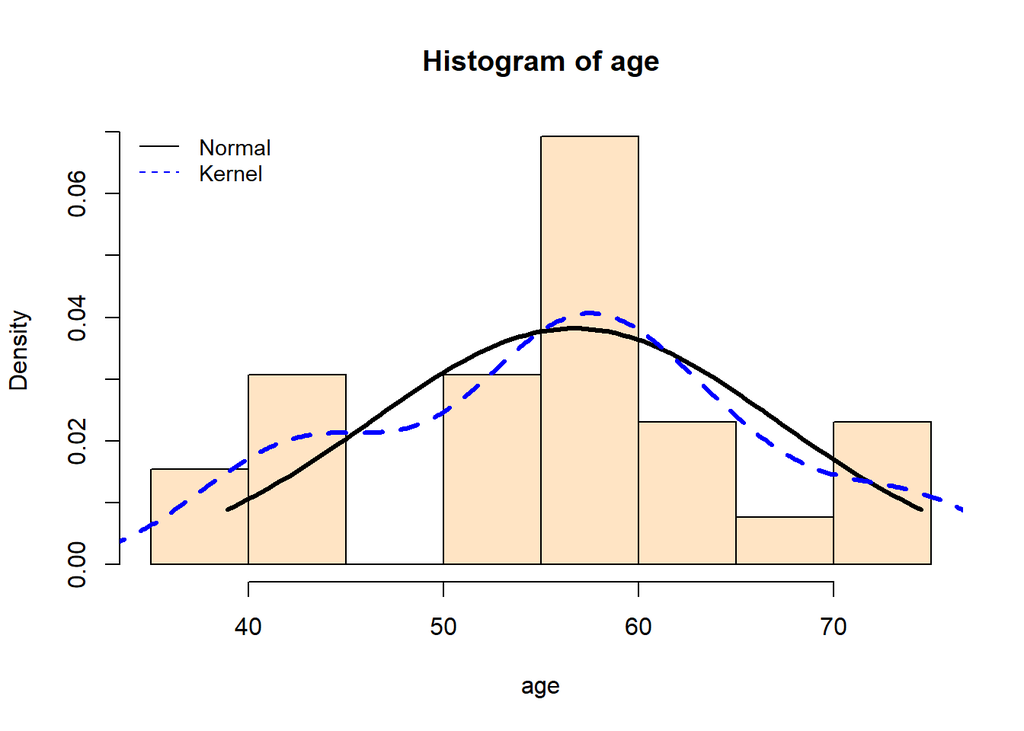

```r
hist (age , col="bisque" , freq=FALSE)
meanx <- mean( age )
sdx <- sd (age)
curve (dnorm(x , mean=mean(x) , sd=sd(x) ) ,
from=min(age ) , to=max(age) , add=TRUE,
lty=1, col="Black " , lwd=3)
kernel <- density (age)
points ( kernel$x  , kernel$y , type="l " ,
lty=2, col="blue " , lwd=3)
legend ("topleft" , c ("Normal " , "Kernel") , lty=c (1 ,2) ,
bty="n" , cex=.9 , col=c (" black " , " blue "))
```

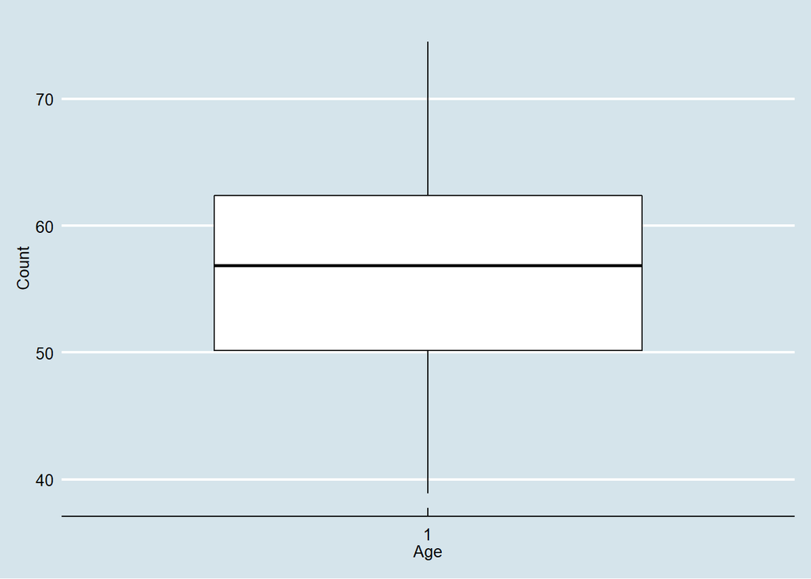

```r
ggboxplot(age, xlab = "Age") +
  labs(x = "Age", y = "Count", main = "Age Normality", fill = "age") +
  theme_economist()
```

```r
skewness(age)
```

```
## [1] 0.04340272
```

```r
kurtosis(age)
```

```
## [1] -0.6562135
```

```r
shapiro.test(age)
```

```
##
##  Shapiro-Wilk normality test
##
## data:  age
## W = 0.96169, p-value = 0.4259
```

```r
t.test(age, mu=56.17,  conf.level = 0.95)
```

```
##
##  One Sample t-test
##
## data:  age
## t = -0.0023009, df = 25, p-value = 0.9982
## alternative hypothesis: true mean is not equal to 56.17
## 95 percent confidence interval:
##  52.08582 60.24507
## sample estimates:
## mean of x
##  56.16544
```

Mean age of population of Intrest is 56.17 and standard Deviation is 10.1. Age of Patients: From 38.89 To 74.5 years.

The Distribution is moderatly Skewed & approximatly Symmetric, and Kurtosis is in acceptable range for bing normally distributed.

From the output, the p-values= 0.4259 > the significance level 0.05, implying that the distribution of the data are not significantly different from the normal distribution.

In other words, we can assume the normality, Normally Distributed.

The p-value of one sample t.test is 0.9982, which is greater than the significance level alpha = 0.05. We can conclude that average Ages is not significantly different from there mean with a p-value = 0.9982.

===============================================================

# 2- Progression:

```r
Count_Prog <- table(ovarian$Progression)
Percent_Prog <- prop.table(Count_Prog)*100

Prog_persent <- as.data.frame(cbind(Count_Prog, Percent_Prog))
Prog_persent
```

```
##                Count_Prog Percent_Prog
## No Progression         11     42.30769
## Progression            15     57.69231
```

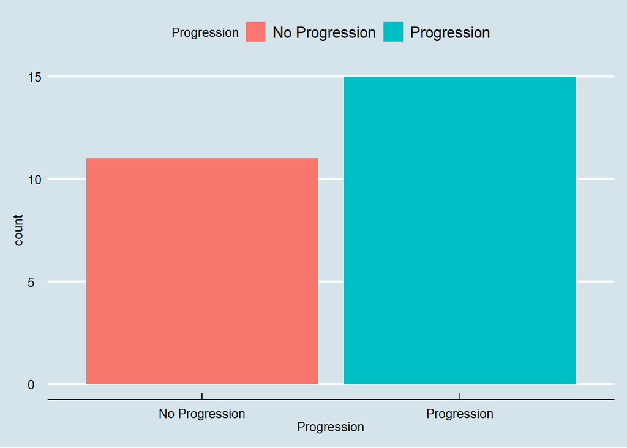

```r
ggplot(ovarian,aes(Progression, fill= Progression)) +
  geom_bar(stat="count") +
  theme_economist()
```

```r
chisq.test(Count_Prog)
```

```
##
##  Chi-squared test for given probabilities
##
## data:  Count_Prog
## X-squared = 0.61538, df = 1, p-value = 0.4328
```

The p-value of the Chi.Square test is 0.4328, which is greater than the significance level alpha = 0.05. We can conclude that Prgoression is significantly commonly distributed with a p-value = 0.4328.

===============================================================

# 3- ECOG Performance Status:

```r
Count_per <- table(ovarian$Performance)
Percent_per <- prop.table(Count_per)*100

per_persent <- as.data.frame(cbind(Count_per, Percent_per))
per_persent
```

```
##      Count_per Percent_per
## High        14    53.84615
## Low         12    46.15385
```

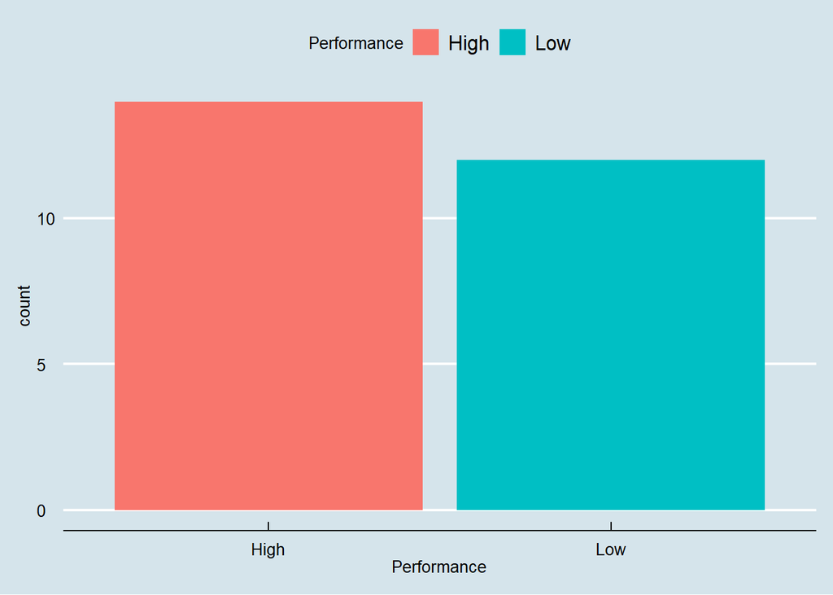

```r
ggplot(ovarian,aes(Performance, fill= Performance)) +
  geom_bar(stat="count") +
  theme_economist()
```

```r
chisq.test(Count_per)
```

```
##
##  Chi-squared test for given probabilities
##
## data:  Count_per
## X-squared = 0.15385, df = 1, p-value = 0.6949
```

The p-value of the Chi.Square test is 0.6949, which is greater than the significance level alpha = 0.05. We can conclude that ECOG Performance Status is significantly commonly distributed with a p-value = 0.6949.

## Second, Survival Analysis:

# Kaplan-Meier Estimator:

```r
survobj <- with(ovarian, Surv(futime, fustat))

surviv <- survfit(survobj ~ 1, data = ovarian)
summary(surviv)
```

```
## Call: survfit(formula = survobj ~ 1, data = ovarian)
##
##  time n.risk n.event survival std.err lower 95% CI upper 95% CI
##    59     26       1    0.962  0.0377        0.890        1.000
##   115     25       1    0.923  0.0523        0.826        1.000
##   156     24       1    0.885  0.0627        0.770        1.000
##   268     23       1    0.846  0.0708        0.718        0.997
##   329     22       1    0.808  0.0773        0.670        0.974
##   353     21       1    0.769  0.0826        0.623        0.949
##   365     20       1    0.731  0.0870        0.579        0.923
##   431     17       1    0.688  0.0919        0.529        0.894
##   464     15       1    0.642  0.0965        0.478        0.862
##   475     14       1    0.596  0.0999        0.429        0.828
##   563     12       1    0.546  0.1032        0.377        0.791
##   638     11       1    0.497  0.1051        0.328        0.752
```

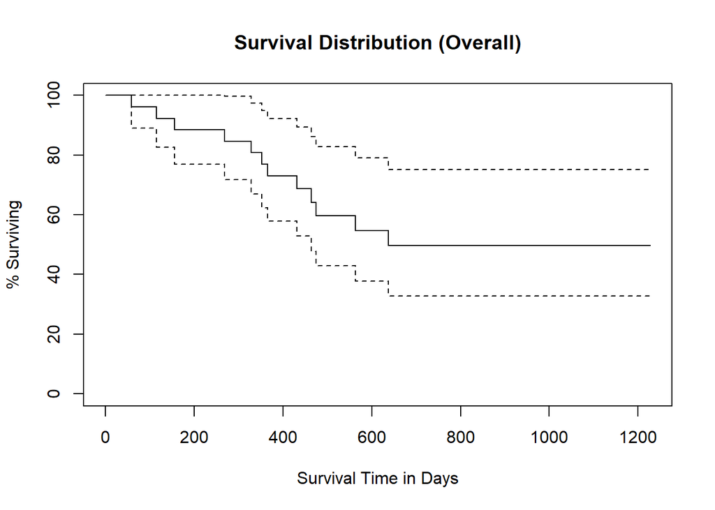

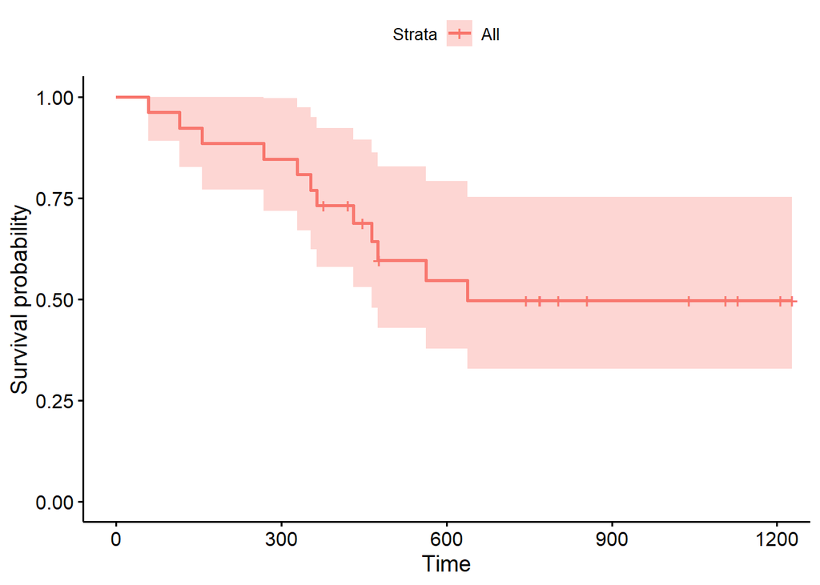

```r
plot(surviv, xlab = "Survival Time in Days", ylab = "% Surviving", yscale = 100, main = "Survival Distribution (Overall)")

ggsurvplot(surviv, data = ovarian, pval = TRUE)
```

## 1- Compare the Survival Distribution Between Old and Young Female Patients (Survival Curves):

```r
surviv1 <- survfit(survobj ~ dummy_Age, data = ovarian)
surviv1
```

```
## Call: survfit(formula = survobj ~ dummy_Age, data = ovarian)
##
##                  n events median 0.95LCL 0.95UCL
## dummy_Age=Old   20     11    563     431      NA
## dummy_Age=Young  6      1     NA      NA      NA
```

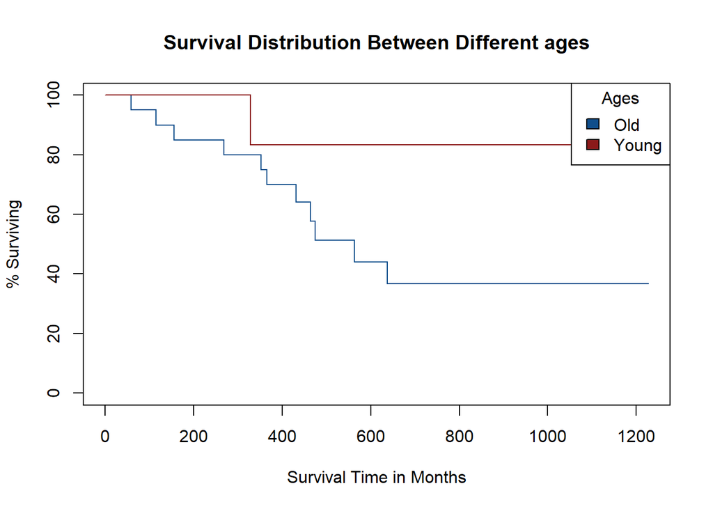

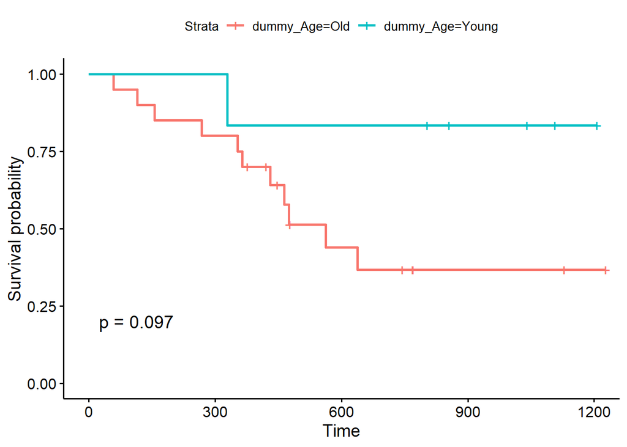

```r
plot(surviv1, xlab = "Survival Time in Months", ylab = "% Surviving", yscale = 100,
     col = c("dodgerblue4", "firebrick4"),
     main = "Survival Distribution Between Different ages")

     legend("topright", title = "Ages", c("Old", "Young"),
     fill= c("dodgerblue4", "firebrick4"))

ggsurvplot(surviv1, data = ovarian, pval = TRUE)
```

```r
survdiff(survobj ~ dummy_Age, data = ovarian)
```

```
## Call:
## survdiff(formula = survobj ~ dummy_Age, data = ovarian)
##
##                  N Observed Expected (O-E)^2/E (O-E)^2/V
## dummy_Age=Old   20       11      8.4     0.804      2.75
## dummy_Age=Young  6        1      3.6     1.876      2.75
##
##  Chisq= 2.7  on 1 degrees of freedom, p= 0.1
```

p-value = 0.1, This means Median Survival Time of old and young patients is not Significantly different.

===============================================================

## 2- Compare the Survival Distribution of Different Progression Status (Survival Curves):

```r
surviv2 <- survfit(survobj ~ ovarian$Progression, data = ovarian)
surviv2
```

```
## Call: survfit(formula = survobj ~ ovarian$Progression, data = ovarian)
##
##                                     n events median 0.95LCL 0.95UCL
## ovarian$Progression=No Progression 11      3     NA     638      NA
## ovarian$Progression=Progression    15      9    464     329      NA
```

[figure not shown]

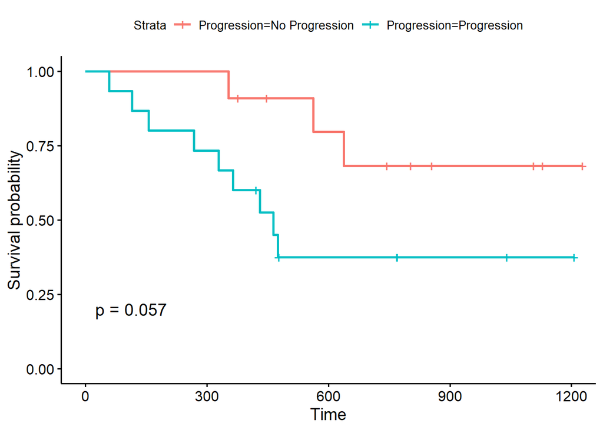

```r
plot(surviv2, xlab = "Survival Time in Months", ylab = "% Surviving", yscale = 100,
     col = c("dodgerblue4", "firebrick4"),
     main = "Survival Distribution Between Different Progression")
     legend("topright", title = "Progression", c("Yes", "No"),
     fill= c("dodgerblue4", "firebrick4"))

ggsurvplot(surviv2, data = ovarian, pval = TRUE)
```

```r
survdiff(survobj ~ ovarian$Progression, data = ovarian)
```

```
## Call:
## survdiff(formula = survobj ~ ovarian$Progression, data = ovarian)
##
##                                     N Observed Expected (O-E)^2/E
## ovarian$Progression=No Progression 11        3     6.26      1.70
## ovarian$Progression=Progression    15        9     5.74      1.85
##                                    (O-E)^2/V
## ovarian$Progression=No Progression      3.62
## ovarian$Progression=Progression         3.62
##
##  Chisq= 3.6  on 1 degrees of freedom, p= 0.06
```

===============================================================

## 3- Compare the Survival Distribution of Different Performance Status (Survival Curves):

```r
surviv3 <- survfit(survobj ~ ovarian$Performance, data = ovarian)
surviv3
```

```
## Call: survfit(formula = survobj ~ ovarian$Performance, data = ovarian)
##
##                           n events median 0.95LCL 0.95UCL
## ovarian$Performance=High 14      5     NA     431      NA
## ovarian$Performance=Low  12      7    563     464      NA
```

[figure not shown]

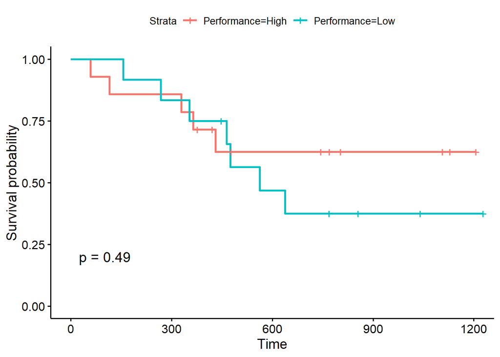

```r
plot(surviv3, xlab = "Survival Time in Months", ylab = "% Surviving", yscale = 100,
     col = c("dodgerblue4", "firebrick4"),
     main = "Survival Distribution Between Different Performance")
     legend("topright", title = "Performance", c("Low", "High"),
     fill= c("dodgerblue4", "firebrick4"))

ggsurvplot(surviv3, data = ovarian, pval = TRUE)
```

```r
survdiff(survobj ~ ovarian$Performance, data = ovarian)
```

```
## Call:
## survdiff(formula = survobj ~ ovarian$Performance, data = ovarian)
##
##                           N Observed Expected (O-E)^2/E (O-E)^2/V
## ovarian$Performance=High 14        5     6.18     0.226     0.468
## ovarian$Performance=Low  12        7     5.82     0.240     0.468
##
##  Chisq= 0.5  on 1 degrees of freedom, p= 0.5
```

p-value = 0.5, This means Median Survival Time between different performance status is not Significantly different.

===============================================================

## 4- Compare the Survival Distribution of Different Treatments (Survival Curves):

```r
surviv4 <- survfit(survobj ~ ovarian$Treatment, data = ovarian)
surviv4
```

```
## Call: survfit(formula = survobj ~ ovarian$Treatment, data = ovarian)
##
##                                    n events median 0.95LCL 0.95UCL
## ovarian$Treatment=Endoxan + Adria 13      5     NA     475      NA
## ovarian$Treatment=Endoxan alone   13      7    638     268      NA
```

```r
summary(surviv4)
```

```
## Call: survfit(formula = survobj ~ ovarian$Treatment, data = ovarian)
##
##                 ovarian$Treatment=Endoxan + Adria
##  time n.risk n.event survival std.err lower 95% CI upper 95% CI
##   353     13       1    0.923  0.0739        0.789        1.000
##   365     12       1    0.846  0.1001        0.671        1.000
##   464      9       1    0.752  0.1256        0.542        1.000
##   475      8       1    0.658  0.1407        0.433        1.000
##   563      7       1    0.564  0.1488        0.336        0.946
##
##                 ovarian$Treatment=Endoxan alone
##  time n.risk n.event survival std.err lower 95% CI upper 95% CI
##    59     13       1    0.923  0.0739        0.789        1.000
##   115     12       1    0.846  0.1001        0.671        1.000
##   156     11       1    0.769  0.1169        0.571        1.000
##   268     10       1    0.692  0.1280        0.482        0.995
##   329      9       1    0.615  0.1349        0.400        0.946
##   431      8       1    0.538  0.1383        0.326        0.891
##   638      5       1    0.431  0.1467        0.221        0.840
```

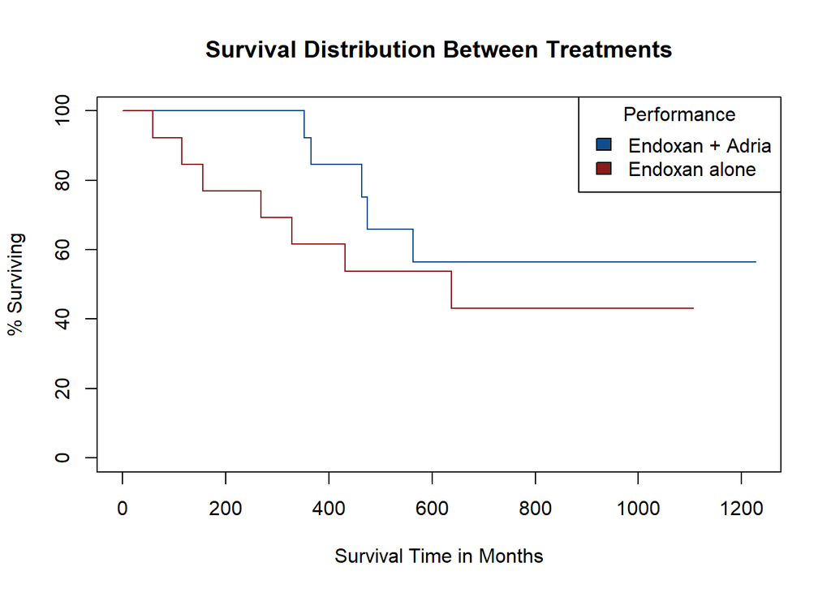

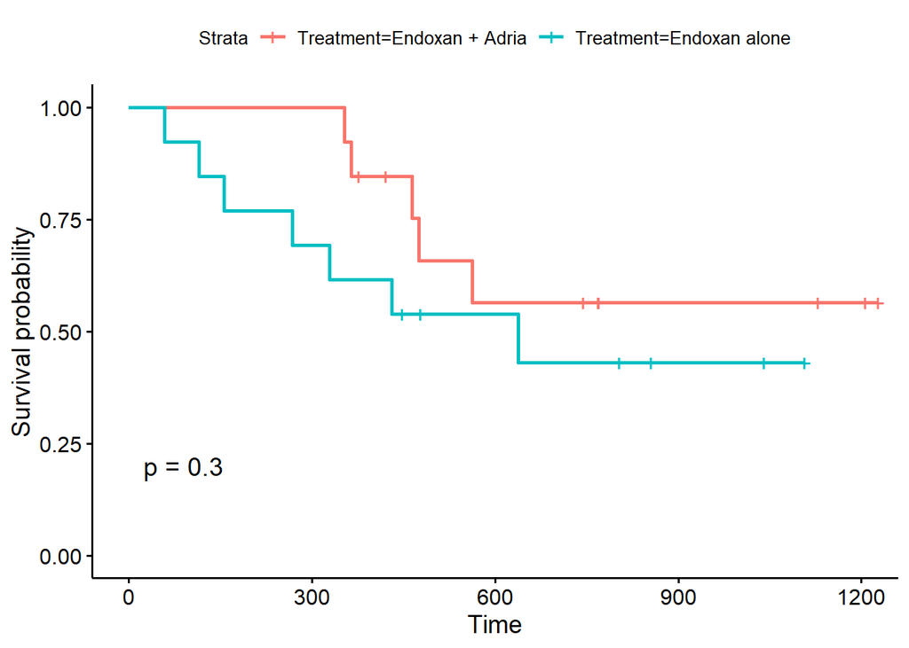

```r
plot(surviv4, xlab = "Survival Time in Months", ylab = "% Surviving", yscale = 100,
     col = c("dodgerblue4", "firebrick4"),
     main = "Survival Distribution Between Treatments")
     legend("topright", title = "Performance", c("Endoxan + Adria", "Endoxan alone"),
     fill= c("dodgerblue4", "firebrick4"))

ggsurvplot(surviv4, data = ovarian, pval = TRUE)
```

```r
survdiff(survobj ~ ovarian$Treatment, data = ovarian)
```

```
## Call:
## survdiff(formula = survobj ~ ovarian$Treatment, data = ovarian)
##
##                                    N Observed Expected (O-E)^2/E (O-E)^2/V
## ovarian$Treatment=Endoxan + Adria 13        5     6.77     0.461      1.06
## ovarian$Treatment=Endoxan alone   13        7     5.23     0.596      1.06
##
##  Chisq= 1.1  on 1 degrees of freedom, p= 0.3
```

===============================================================

## 4- Progression Free Survival:

```r
stat1 <- survfit(Surv(futime, fustat) ~ 1, data = ovarian)
Prog1 <- survfit(Surv(futime, resid.ds) ~ 1, data = ovarian)

Fitting <- list(OS = stat1, PFS = Prog1)
Fitting
```

```
## $OS
## Call: survfit(formula = Surv(futime, fustat) ~ 1, data = ovarian)
##
##       n  events  median 0.95LCL 0.95UCL
##      26      12     638     464      NA
##
## $PFS
## Call: survfit(formula = Surv(futime, resid.ds) ~ 1, data = ovarian)
##
##       n  events  median 0.95LCL 0.95UCL
##      26      15     769     464      NA
```

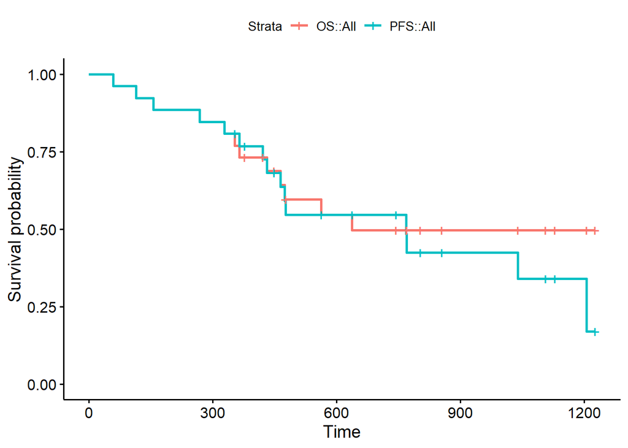

```r
ggsurvplot_combine(Fitting, ovarian)
```

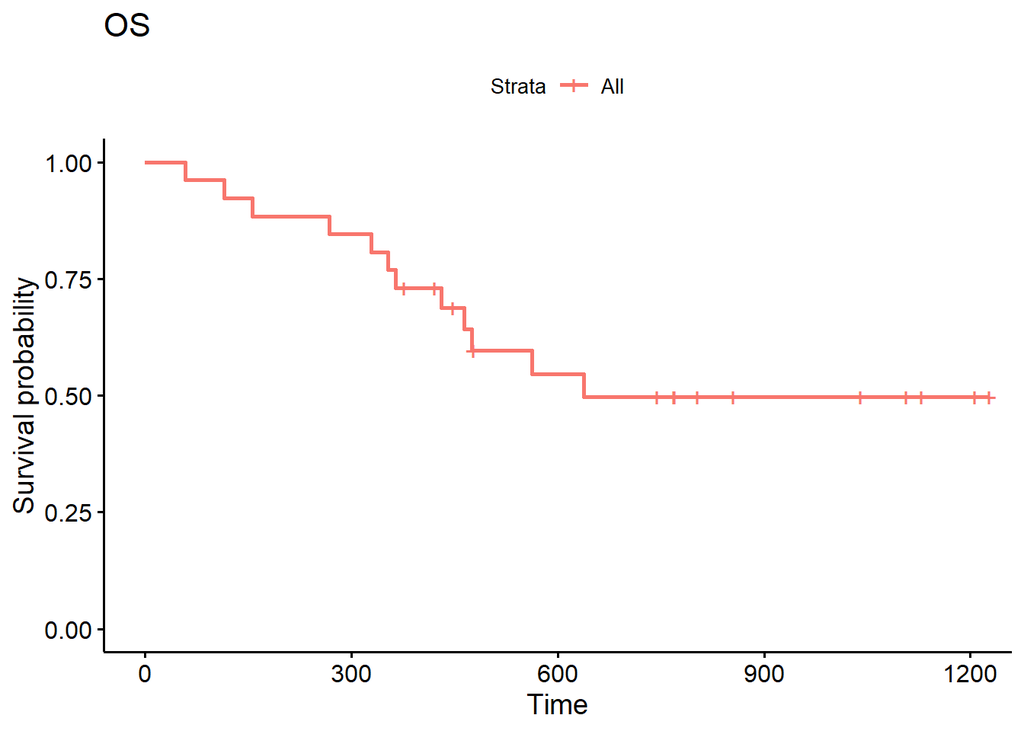

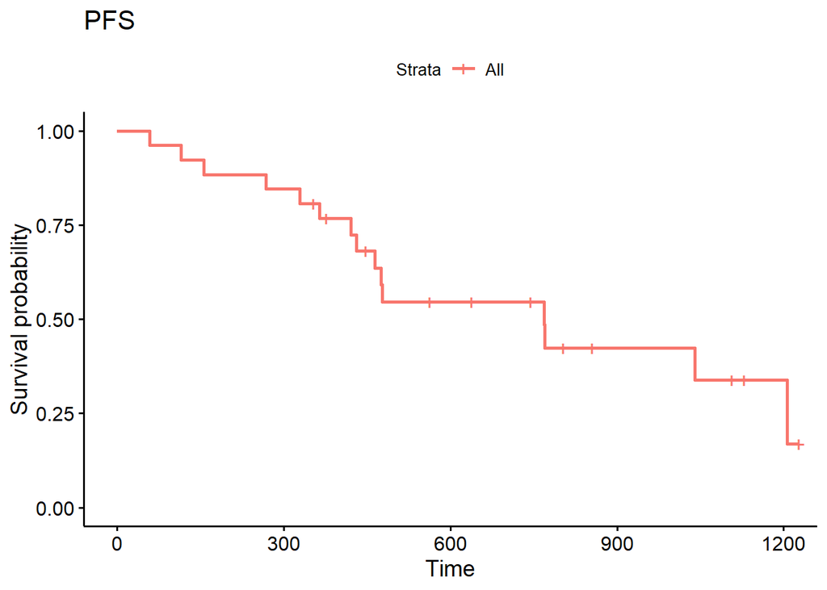

```
##
## attr(,"class")
## [1] "list"            "ggsurvplot_list"
```

```r
ggsurvplot(Fitting, data = ovarian, pval = TRUE)
```

## Third, Cox Regression:

# refrence = Endoxan alone:

```r
survobj <- with(ovarian, Surv(futime, fustat))

Model1 <- coxph(survobj ~ rx, data = ovarian)
summary(Model1)
```

```
## Call:
## coxph(formula = survobj ~ rx, data = ovarian)
##
##   n= 26, number of events= 12
##
##       coef exp(coef) se(coef)      z Pr(>|z|)
## rx -0.5964    0.5508   0.5870 -1.016     0.31
##
##    exp(coef) exp(-coef) lower .95 upper .95
## rx    0.5508      1.816    0.1743      1.74
##
## Concordance= 0.608  (se = 0.07 )
## Likelihood ratio test= 1.05  on 1 df,   p=0.3
## Wald test            = 1.03  on 1 df,   p=0.3
## Score (logrank) test = 1.06  on 1 df,   p=0.3
```

```r
progobj <- with(ovarian, Surv(futime, resid.ds))

Model11 <- coxph(progobj ~ rx, data = ovarian)
summary(Model11)
```

```
## Call:
## coxph(formula = progobj ~ rx, data = ovarian)
##
##   n= 26, number of events= 15
##
##       coef exp(coef) se(coef)      z Pr(>|z|)
## rx -0.5104    0.6002   0.5413 -0.943    0.346
##
##    exp(coef) exp(-coef) lower .95 upper .95
## rx    0.6002      1.666    0.2078     1.734
##
## Concordance= 0.606  (se = 0.068 )
## Likelihood ratio test= 0.9  on 1 df,   p=0.3
## Wald test            = 0.89  on 1 df,   p=0.3
## Score (logrank) test = 0.91  on 1 df,   p=0.3
```

===============================================================

# Survival per Treatment from other variables:

- Hazard of Death from ovarian cancer considering th Covarience:

```r
Model2 <- coxph(survobj ~ rx+  age + resid.ds + ecog.ps, data = ovarian)
summary(Model2)
```

```
## Call:
## coxph(formula = survobj ~ rx + age + resid.ds + ecog.ps, data = ovarian)
##
##   n= 26, number of events= 12
##
##              coef exp(coef) se(coef)      z Pr(>|z|)
## rx       -0.91450   0.40072  0.65332 -1.400  0.16158
## age       0.12481   1.13294  0.04689  2.662  0.00777 **
## resid.ds  0.82619   2.28459  0.78961  1.046  0.29541
## ecog.ps   0.33621   1.39964  0.64392  0.522  0.60158
## ---
## Signif. codes:  0 '***' 0.001 '**' 0.01 '*' 0.05 '.' 0.1 ' ' 1
##
##          exp(coef) exp(-coef) lower .95 upper .95
## rx          0.4007     2.4955    0.1114     1.442
## age         1.1329     0.8827    1.0335     1.242
## resid.ds    2.2846     0.4377    0.4861    10.738
## ecog.ps     1.3996     0.7145    0.3962     4.945
##
## Concordance= 0.807  (se = 0.068 )
## Likelihood ratio test= 17.04  on 4 df,   p=0.002
## Wald test            = 14.25  on 4 df,   p=0.007
## Score (logrank) test = 20.81  on 4 df,   p=3e-04
```

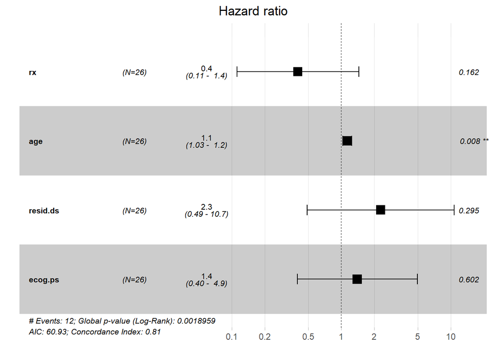

```r
ggforest(Model2, data = ovarian)
```

1- Older Patients has higher risk of death, this risk is significant (p-value = 0.00777) 2- likelihood ratio test Significance decreased from 0.3 to 0.002.

# Evaluate Proportional Hazard Assumption:

```r
cox.zph(Model2)
```

```
##              rho  chisq     p
## rx        0.1325 0.2001 0.655
## age      -0.0399 0.0262 0.871
## resid.ds -0.1417 0.2463 0.620
## ecog.ps   0.4845 1.8819 0.170
## GLOBAL        NA 3.3609 0.499
```

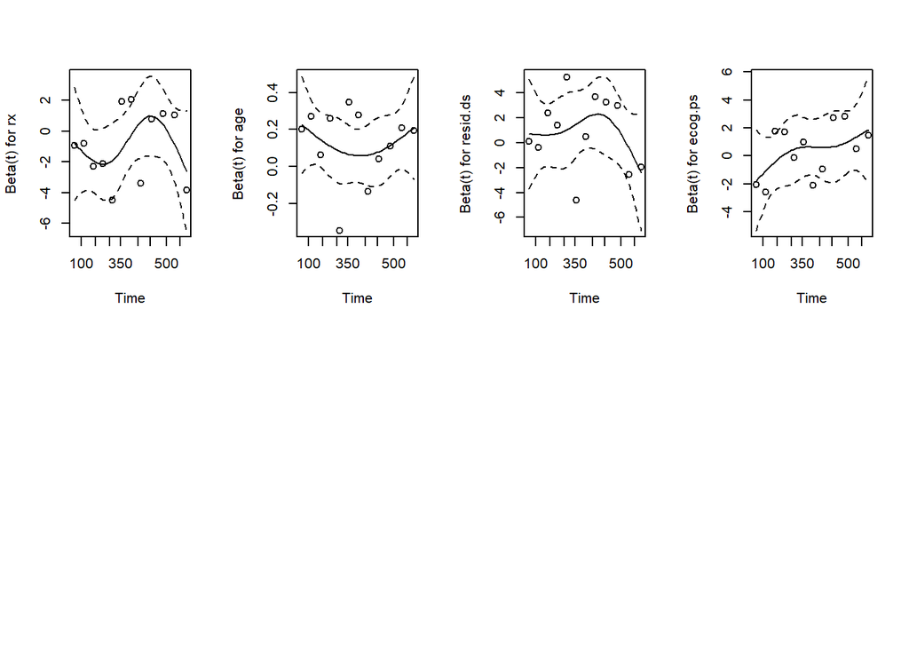

```r
par(mfrow = c(2, 4))
plot(cox.zph(Model2), data = ovarian)
```

# By using the Schoenfeld residuals against the transformed time:

From the output above, the test is not statistically significant for each of the covariates, and the global test is also not statistically significant. Therefore, we can assume the proportional hazards.

1- rho: Pearson’s correlation between the scaled Shoenfeld residuals and Time. The value of ecog.ps has higher corralation (0.4845) from over covariate, and resid.ds has the least corrlation (-0.1417). All in positive direction except age and resid.ds in Negative direction.

2- chisq: The correlation coefficient follows a chi-square distribution and the statistic is present in the second column.

3- p-value: P value is given for each covariate.

4- For the global test there is no correlation and NA is entered into the cell.

# Progression Free Survival per Treatment from other variables:

- Hazard of Progression from ovarian cancer considering th Covarience:

```r
progobj <- with(ovarian, Surv(futime, resid.ds))

Model22 <- coxph(progobj ~ rx+  age + fustat + ecog.ps, data = ovarian)

summary(Model22)
```

```
## Call:
## coxph(formula = progobj ~ rx + age + fustat + ecog.ps, data = ovarian)
##
##   n= 26, number of events= 15
##
##             coef exp(coef) se(coef)      z Pr(>|z|)
## rx      -0.87491   0.41690  0.60341 -1.450  0.14708
## age      0.11938   1.12679  0.04151  2.876  0.00403 **
## fustat   2.81365  16.67057  0.94903  2.965  0.00303 **
## ecog.ps -1.54115   0.21413  0.66405 -2.321  0.02030 *
## ---
## Signif. codes:  0 '***' 0.001 '**' 0.01 '*' 0.05 '.' 0.1 ' ' 1
##
##         exp(coef) exp(-coef) lower .95 upper .95
## rx         0.4169    2.39865   0.12776    1.3604
## age        1.1268    0.88747   1.03875    1.2223
## fustat    16.6706    0.05999   2.59497  107.0948
## ecog.ps    0.2141    4.66997   0.05827    0.7869
##
## Concordance= 0.876  (se = 0.038 )
## Likelihood ratio test= 25.71  on 4 df,   p=4e-05
## Wald test            = 15.51  on 4 df,   p=0.004
## Score (logrank) test = 25.95  on 4 df,   p=3e-05
```

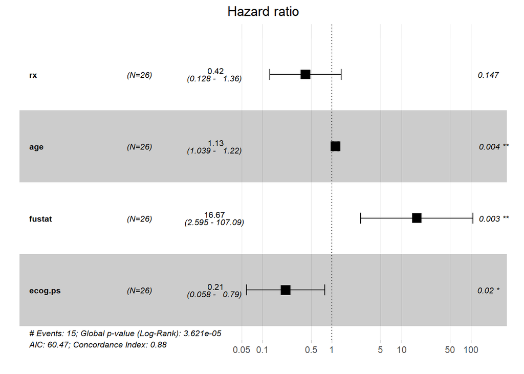

```r
ggforest(Model22, data = ovarian)
```

# Evaluate Proportional Hazard Assumption:

```r
cox.zph(Model22)
```

```
##            rho chisq     p
## rx       0.182 0.425 0.514
## age     -0.300 1.478 0.224
## fustat  -0.171 0.402 0.526
## ecog.ps  0.194 0.625 0.429
## GLOBAL      NA 1.951 0.745
```

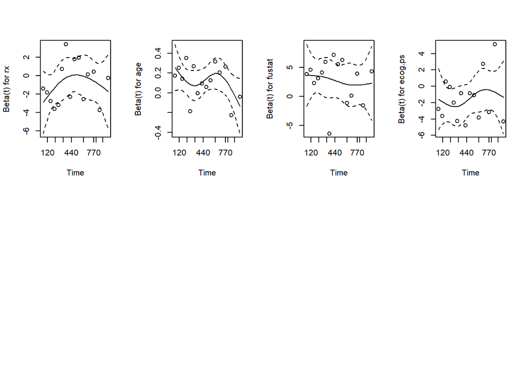

```r
par(mfrow = c(2, 4))
plot(cox.zph(Model22), data = ovarian)
```

# By using the Schoenfeld residuals against the transformed time:

From the output above, the test is not statistically significant for each of the covariates, and the global test is also not statistically significant. Therefore, we can assume the proportional hazards.

1- rho: Pearson’s correlation between the scaled Shoenfeld residuals and Time. The value of ecog.ps has higher corralation (0.194) from over covariate, and age has the least corrlation (-0.300). All in positive direction except age and fustat in Negative direction.

2- chisq: The correlation coefficient follows a chi-square distribution and the statistic is present in the second column.

3- p-value: P value is given for each covariate.

4- For the global test there is no correlation and NA is entered into the cell.